# R6-generator-datatypes

Rob Challen

19/10/2020

# Datatype conversion

R and Java have quite different philosophy on datatypes that mean that loss less round tripping of data through the limited expressibility of the JNI bridge is a non trivial exercise. This is why a code generation library is valuable as it removes the need for developers to understand the grim complexity of the details. The following areas proved to be the most difficult:

- In R everything is a vector. In Java vectors are closest in nature to collections, either Lists or insertion ordered Maps.
- In Java there is a fundamental difference between a single value and an array of values. In R they are interchangeable.
- In R everything can be named. In Java data is not “named” as such unless it is in a Map.
- Java distinguishes between primitive and boxed data types. R has no primitive type except raw bytes.
- JNI only really natively supports primitive data types, and arrays thereof.
- R Dataframes are naturally column based structures. Java is generally written to operate iteratively on streams of objects, which are more like rows.
- R lists are complex untyped structures with more similarity to JSON trees than to Java Collections.
- R is 1 based, java is 0 based for indexes.
- R has typed NA values. Java null is untyped.
- Java void and R NULL are not exactly the same conceptually, as an R variable can be NULL but a Java variable can never be void. Boxed Void types in Java are the programming equivalent of Schrodinger’s cat.

By inspecting the Java code at compilation time, and by imposing constraints on the types of data transferred between R and Java, it is possible to use a combination of convention, data-type coercion, and type checking to ensure that inputs to Java code from R are type safe, and (almost) 100% faithful copies of their R equivalents and vice versa. This differs in approach from which performs dynamic data conversion from R types to generic R data structures. This is harder to make consistent and requires a degree of introspection, during the marshalling and unmarshalling process. Enforcing rigid type systems on the interface between R and Java allows the simpler transformation to be made, based on the strongly typed Java code at compile time, which should result in faster but less flexible data transfer.

## Round tripping data from R to Java to R

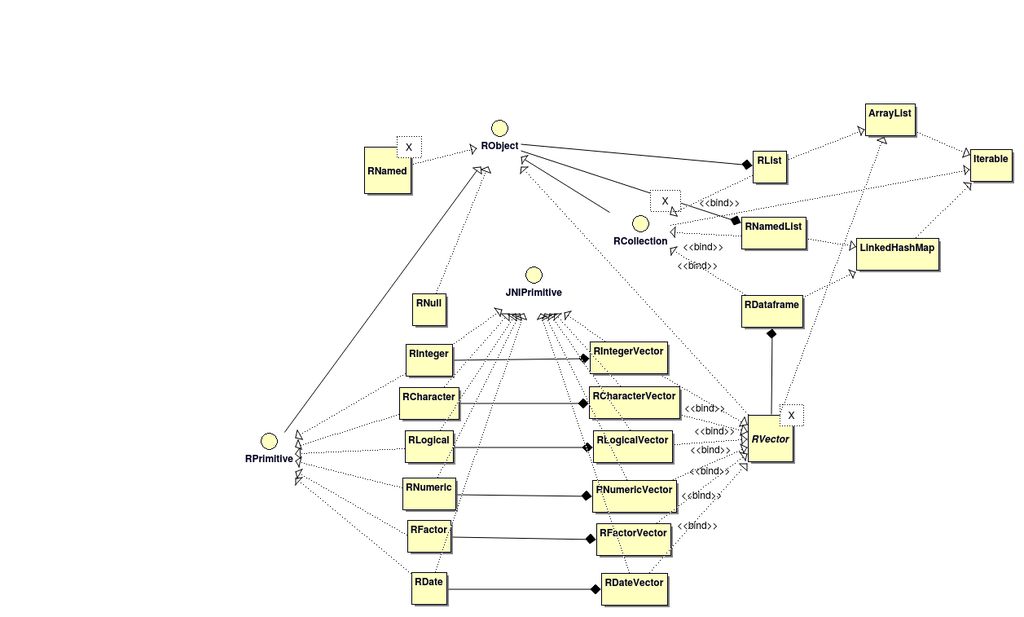

class-hierarchy

### Nulls and voids

Ensuring an R NULL value is correctly returned requires a placeholder class in Java. This is `uk.co.terminological.rjava.types.RNull` and it enforces some of the identity constraints. Java void types can be best represented as `invisible(NULL)` which is almost the same as not returning anything from a method.

```java
    @RMethod
    public RNull bounceNull(RNull x) {
        log.info("java: "+x);
        System.out.println(x.rCode());
        return x;
    }

    @RMethod
    public void bounceVoid() {
        log.info("java void");
    }
```

```r
# devtools::install("~/Git/r6-generator-maven-plugin-test/r-library/")
J = testRapi::JavaApi$get()
```

```
## Adding to classpath: /home/terminological/R/x86_64-pc-linux-gnu-library/3.6/testRapi/java/log4j-api-2.13.3.jar
## Adding to classpath: /home/terminological/R/x86_64-pc-linux-gnu-library/3.6/testRapi/java/log4j-core-2.13.3.jar
## Adding to classpath: /home/terminological/R/x86_64-pc-linux-gnu-library/3.6/testRapi/java/log4j-slf4j-impl-2.13.3.jar
## Adding to classpath: /home/terminological/R/x86_64-pc-linux-gnu-library/3.6/testRapi/java/r6-generator-maven-plugin-test-master-SNAPSHOT-jar-with-dependencies.jar
## Adding to classpath: /home/terminological/R/x86_64-pc-linux-gnu-library/3.6/testRapi/java/slf4j-api-1.7.22.jar
```

```
## 2020-10-27 23:00:52,665 INFO testRapi [main] Initialised testRapi
```

```r
b = J$BounceTest$new()
```

```
## 2020-10-27 23:00:52,669 INFO uk.co.terminological.rjava.test.BounceTest [main] Tests the round tripping of supported datatypes
```

```r
b$bounceNull(NULL)
```

```
## 2020-10-27 23:00:52,673 INFO uk.co.terminological.rjava.test.BounceTest [main] java: NULL
## NULL
```

```r
b$bounceVoid()
```

```
## 2020-10-27 23:00:52,674 INFO uk.co.terminological.rjava.test.BounceTest [main] java void
```

### Character data

Strings are the least contentious format with high similarity between R and Java, so long as we are all using UTF-8. An R character vector can be transferred to Java seamlessly except for the fact that asit is transferred it is as an array of characters in JNI. A java equivalent of `uk.co.terminological.rjava.types.RCharacter` is provided to mark the object as an R compatible datatype, in general though `java.lang.String` can used instead of singleton strings. For character vectors we have `uk.co.terminological.rjava.types.RCharacterVector` which is a specialised java collection of `uk.co.terminological.rjava.types.RCharacter`s

```java
    @RMethod
    public String bounceString(String x) {
        log.info("java: "+x);
        return x;
    }


    @RMethod
    public RCharacter bounceCharacter(RCharacter x) {
        log.info("java: "+x);
        System.out.println(x.rCode());
        return x;
    }

    @RMethod
    public RCharacterVector bounceCharacterVector(RCharacterVector x) {
        log.info("java: "+x);
        System.out.println(x.rCode());
        return x;
    }
```

```r
b$bounceString("Hello")
```

```
## 2020-10-27 23:00:52,687 INFO uk.co.terminological.rjava.test.BounceTest [main] java: Hello
```

```
## [1] "Hello"
```

```r
b$bounceCharacter("Hello")
```

```
## 2020-10-27 23:00:52,689 INFO uk.co.terminological.rjava.test.BounceTest [main] java: Hello
## 'Hello'
```

```
## [1] "Hello"
```

```r
b$bounceCharacterVector(c("Hello","World"))
```

```
## 2020-10-27 23:00:52,696 INFO uk.co.terminological.rjava.test.BounceTest [main] java: <rcharacter> Hello, World, ...
## c('Hello', 'World')
```

```
## [1] "Hello" "World"
```

### Numeric data

Numerics in R can be represented a number of ways in Java, and various Java types, such as `java.lang.Double`, `java.lang.Float`, `java.math.BigDecimal`, `java.lang.Long`, and their primitive counterparts are best be represented by R numerics. The `uk.co.terminological.rjava.types.RNumeric` type allows Java programmers to dynamically convert R Numerics to the desired native type, and the `uk.co.terminological.rjava.RConverter` provides various methods to convert native java types to `uk.co.terminological.rjava.types.RNumeric`s. This also handles the special values of `Inf` and `-Inf`, `NaN`, and `NA_real_` and their equivalent values in Java. To support the use of native Java, singleton `RNumeric`s can be substituted with primitive Java `double` as long as the inputs can never be `NA_real_`. Vector inputs are handled in the same way as before

```java
    @RMethod
    public double bounceDouble(double x) {
        log.info("java: "+x);
        return x;
    }

    @RMethod
    public RNumeric bounceNumeric(RNumeric x) {
        log.info("java: "+x);
        System.out.println(x.rCode());
        return x;
    }

    @RMethod
    public RNumericVector bounceNumericVector(RNumericVector x) {
        log.info("java: "+x);
        System.out.println(x.rCode());
        return x;
    }
```

```r
b$bounceDouble(1.23)
```

```
## 2020-10-27 23:00:52,713 INFO uk.co.terminological.rjava.test.BounceTest [main] java: 1.23
```

```
## [1] 1.23
```

```r
# throws an error as primitive double cannot be null
try(b$bounceDouble(NA_real_))
```

```
## Error in self$.api$.toJava$double(x) :
##   cant use NA as input to java double
```

```r
b$bounceNumeric(4.6)
```

```
## 2020-10-27 23:00:52,717 INFO uk.co.terminological.rjava.test.BounceTest [main] java: 4.6
## 4.6
```

```
## [1] 4.6
```

```r
# This works and is correctly round tripped but Java thinks the value is a NaN rather than a NA. This is a bug but has limited impact.
b$bounceNumeric(NA_real_)
```

```
## 2020-10-27 23:00:52,718 INFO uk.co.terminological.rjava.test.BounceTest [main] java: NaN
## NaN
```

```
## [1] NA
```

```r
b$bounceNumeric(Inf)
```

```
## 2020-10-27 23:00:52,720 INFO uk.co.terminological.rjava.test.BounceTest [main] java: Infinity
## Inf
```

```
## [1] Inf
```

```r
b$bounceNumeric(-Inf)
```

```
## 2020-10-27 23:00:52,721 INFO uk.co.terminological.rjava.test.BounceTest [main] java: -Infinity
## -Inf
```

```
## [1] -Inf
```

```r
b$bounceNumeric(0/0)
```

```
## 2020-10-27 23:00:52,722 INFO uk.co.terminological.rjava.test.BounceTest [main] java: NaN
## NaN
```

```
## [1] NaN
```

```r
# Wrongly typed input is coerced to numerics
b$bounceNumericVector(c(2L,5L,34L))
```

```
## 2020-10-27 23:00:52,724 INFO uk.co.terminological.rjava.test.BounceTest [main] java: <rnumeric> 2.0, 5.0, 34.0, ...
## c(2.0, 5.0, 34.0)
```

```
## [1]  2  5 34
```

```r
b$bounceNumericVector(c(2.3,4.6,NA_real_,34,NaN,Inf,-Inf))
```

```
## 2020-10-27 23:00:52,729 INFO uk.co.terminological.rjava.test.BounceTest [main] java: <rnumeric> 2.3, 4.6, NaN, 34.0, NaN, Infinity, -Infinity, ...
## c(2.3, 4.6, NaN, 34.0, NaN, Inf, -Inf)
```

```
## [1]  2.3  4.6   NA 34.0  NaN  Inf -Inf
```

### Integer data

In an identical way to above `uk.co.terminological.rjava.types.RInteger` types hold integer values. R inputs to Java functions are coerced to integers and an error thrown if this is not possible. The primitive `int` Java type can be used for singletons if they are not `NA`, and vectors are handled in the same way.

```java
    @RMethod
    public int bounceInt(int x) {
        log.info("java: "+x);
        return x;
    }

    @RMethod
    public RInteger bounceInteger(RInteger x) {
        log.info("java: "+x);
        System.out.println(x.rCode());
        return x;
    }

    @RMethod
    public RIntegerVector bounceIntegerVector(RIntegerVector x) {
        log.info("java: "+x);
        System.out.println(x.rCode());
        return x;
    }
```

```r
b$bounceInt(1)
```

```
## 2020-10-27 23:00:52,742 INFO uk.co.terminological.rjava.test.BounceTest [main] java: 1
```

```
## [1] 1
```

```r
b$bounceInteger(3)
```

```
## 2020-10-27 23:00:52,744 INFO uk.co.terminological.rjava.test.BounceTest [main] java: 3
## 3L
```

```
## [1] 3
```

```r
b$bounceIntegerVector(c(2L,3L,4L))
```

```
## 2020-10-27 23:00:52,746 INFO uk.co.terminological.rjava.test.BounceTest [main] java: <rinteger> 2, 3, 4, ...
## c(2L, 3L, 4L)
```

```
## [1] 2 3 4
```

```r
b$bounceIntegerVector(c(2,3,4))
```

```
## 2020-10-27 23:00:52,754 INFO uk.co.terminological.rjava.test.BounceTest [main] java: <rinteger> 2, 3, 4, ...
## c(2L, 3L, 4L)
```

```
## [1] 2 3 4
```

```r
b$bounceIntegerVector(c(2L,NA,4L))
```

```
## 2020-10-27 23:00:52,756 INFO uk.co.terminological.rjava.test.BounceTest [main] java: <rinteger> 2, NA, 4, ...
## c(2L, NA, 4L)
```

```
## [1]  2 NA  4
```

### Factors

Factors are somewhat complicated as a individual factor only makes sense in the context of a vector of possible options. However the `uk.co.terminological.rjava.types.RFactor` type and `uk.co.terminological.rjava.types.RFactorVector` collection allow information to be retained about the values and labels for R Factors. There is support for mapping R factors to Java `Enum` classes which is provided by `uk.co.terminological.rjava.RConverter` and creating R ordered factors from `Enum`s.

```java
    @RMethod
    public RFactor bounceFactor(RFactor x) {
        log.info("java: "+x);
        System.out.println(x.rCode());
        return x;
    }

    @RMethod
    public RFactorVector bounceFactorVector(RFactorVector x) {
        log.info("java: "+x);
        System.out.println(x.rCode());
        return x;
    }
```

```r
factorVec = as.factor(c("a","b","c","b","a"))
b$bounceFactor(as.factor(factorVec[[1]]))
```

```
## 2020-10-27 23:00:52,770 INFO uk.co.terminological.rjava.test.BounceTest [main] java: a
## 'a'
```

```
## [1] "a"
```

```r
b$bounceFactorVector(factorVec)
```

```
## 2020-10-27 23:00:52,772 INFO uk.co.terminological.rjava.test.BounceTest [main] java: <rfactor> a, b, c, b, a, ...
## ordered(x=c('a', 'b', 'c', 'b', 'a'),labels=c('a', 'b', 'c'))
```

```
## [1] a b c b a
## Levels: a < b < c
```

### Dates

Date support is provided by `uk.co.terminological.rjava.types.RDate` which allows R Date and POSIXt tyeps to be represented in Java as `java.time.LocalDate`s. Vectors of dates are also supported as before. There is currently no support for datetime classes but this is a possible enhancement.

```java
    @RMethod
    public RDate bounceDate(RDate x) {
        log.info("java: "+x);
        System.out.println(x.rCode());
        return x;
    }

    @RMethod
    public RDateVector bounceDateVector(RDateVector x) {
        log.info("java: "+x);
        System.out.println(x.rCode());
        return x;
    }
```

```r
b$bounceDate(as.Date("2001-02-03"))
```

```
## 2020-10-27 23:00:52,795 INFO uk.co.terminological.rjava.test.BounceTest [main] java: 2001-02-03
## as.Date('2001-02-03','%Y-%m-%d')
```

```
## [1] "2001-02-03"
```

```r
class(b$bounceDate(as.Date("2001-02-03")))
```

```
## 2020-10-27 23:00:52,797 INFO uk.co.terminological.rjava.test.BounceTest [main] java: 2001-02-03
## as.Date('2001-02-03','%Y-%m-%d')
```

```
## [1] "Date"
```

```r
b$bounceDateVector(as.Date(c("2001-02-03","2001-02-04","2001-02-05")))
```

```
## 2020-10-27 23:00:52,800 INFO uk.co.terminological.rjava.test.BounceTest [main] java: <rdate> 2001-02-03, 2001-02-04, 2001-02-05, ...
## as.Date(c('2001-02-03', '2001-02-04', '2001-02-05'),'%Y-%m-%d')
```

```
## [1] "2001-02-03" "2001-02-04" "2001-02-05"
```

```r
b$bounceDateVector(as.Date(c("2001-02-03",NA,"2001-02-05")))
```

```
## 2020-10-27 23:00:52,803 INFO uk.co.terminological.rjava.test.BounceTest [main] java: <rdate> 2001-02-03, NA, 2001-02-05, ...
## as.Date(c('2001-02-03', 'NA', '2001-02-05'),'%Y-%m-%d')
```

```
## [1] "2001-02-03" NA           "2001-02-05"
```

### Logicals

R logicals are mapped to `uk.co.terminological.rjava.types.RLogical` objects which can represent `NA_logical_` values faithfully. If `NA` values are not needed then primitive `boolean` types can be substituted as before, and vectors work as before.

```java
    @RMethod
    public RLogical bounceLogical(RLogical x) {
        log.info("java: "+x);
        System.out.println(x.rCode());
        return x;
    }

    @RMethod
    public RLogicalVector bounceLogicalVector(RLogicalVector x) {
        log.info("java: "+x);
        System.out.println(x.rCode());
        return x;
    }
```

```r
b$bounceLogical(TRUE)
```

```
## 2020-10-27 23:00:52,814 INFO uk.co.terminological.rjava.test.BounceTest [main] java: true
## TRUE
```

```
## [1] TRUE
```

```r
b$bounceLogicalVector(c(TRUE,TRUE,FALSE))
```

```
## 2020-10-27 23:00:52,816 INFO uk.co.terminological.rjava.test.BounceTest [main] java: <rlogical> true, true, false, ...
## c(TRUE, TRUE, FALSE)
```

```
## [1]  TRUE  TRUE FALSE
```

```r
b$bounceLogicalVector(c(TRUE,NA,FALSE))
```

```
## 2020-10-27 23:00:52,818 INFO uk.co.terminological.rjava.test.BounceTest [main] java: <rlogical> true, NA, false, ...
## c(TRUE, NA, FALSE)
```

```
## [1]  TRUE    NA FALSE
```

### Dataframes

In Java R dataframes are modelled as a named collection of `uk.co.terminological.rjava.types.RVector<?>` of undetermined type. This is represented internally as a column wise Map, but the `uk.co.terminological.rjava.types.RDataframes` class contains a number of methods to make using dataframes intuitive in Java including support for Iterable and Stream interfaces that operate row-wise over the data, or which can map typed columns to a stream of proxy objects satisfying an interface specification supplied by the developer (more examples TBD). The dataframe can support any column with vector data types mentioned above. At present however it does not support named rows, as the focus is on tidy dataframes.

```java
    @RMethod
    public RDataframe bounceDataframe(RDataframe x) {
        log.info("java: "+x);
        System.out.println(x.rCode());
        System.out.println(x.rConversion());
        return x;
    }
```

```r
b$bounceDataframe(tibble::tibble(
  x=c(0,1,2),
  y=c(3L,2L,1L)
))
```

```
## 2020-10-27 23:00:52,833 INFO uk.co.terminological.rjava.test.BounceTest [main] java: x: <rnumeric> 0.0, 1.0, 2.0, ...
## y: <rinteger> 3, 2, 1, ...
## tibble::tibble(x=c(0.0, 1.0, 2.0), y=c(3L, 2L, 1L))
## function(jObj) {
## convert_0 = function(jObj) as.numeric(rJava::.jcall(jObj,returnSig='[D',method='rPrimitive'))
## convert_1 = function(jObj) as.integer(rJava::.jcall(jObj,returnSig='[I',method='rPrimitive'))
## tmp_0 = rJava::.jcall(obj=jObj,returnSig='Luk/co/terminological/rjava/types/RVector;',method='rColumn','x')
## tmp_0 = rJava::.jcast(tmp_0,new.class='Luk/co/terminological/rjava/types/RNumericVector;')
## tmp_1 = rJava::.jcall(obj=jObj,returnSig='Luk/co/terminological/rjava/types/RVector;',method='rColumn','y')
## tmp_1 = rJava::.jcast(tmp_1,new.class='Luk/co/terminological/rjava/types/RIntegerVector;')
##
## return(tibble::tibble(
## `x` = convert_0(tmp_0),
## `y` = convert_1(tmp_1)
## ))
## }
```

```
## # A tibble: 3 x 2
##       x     y
##   <dbl> <int>
## 1     0     3
## 2     1     2
## 3     2     1
```

```r
b$bounceDataframe(tibble::tibble(
  u=factorVec[1:3],
  v=c(TRUE,NA,FALSE),
  w=c("alpha",NA,"gamma"),
  x=c(0,1,2),
  y=c(3L,2L,1L),
  z=as.Date(c("2001-02-03",NA,"2001-02-05"))
))
```

```
## 2020-10-27 23:00:52,890 INFO uk.co.terminological.rjava.test.BounceTest [main] java: u: <rfactor> a, b, c, ...
## v: <rlogical> true, NA, false, ...
## w: <rcharacter> alpha, NA, gamma, ...
## x: <rnumeric> 0.0, 1.0, 2.0, ...
## y: <rinteger> 3, 2, 1, ...
## z: <rdate> 2001-02-03, NA, 2001-02-05, ...
## tibble::tibble(u=ordered(x=c('a', 'b', 'c'),labels=c('a', 'b', 'c')), v=c(TRUE, NA, FALSE), w=c('alpha', NA, 'gamma'), x=c(0.0, 1.0, 2.0), y=c(3L, 2L, 1L), z=as.Date(c('2001-02-03', 'NA', '2001-02-05'),'%Y-%m-%d'))
## function(jObj) {
## convert_0 = function(jObj) ordered(
##  x = rJava::.jcall(jObj,returnSig='[I',method='rValues'),
##  labels = rJava::.jcall(jObj,returnSig='[Ljava/lang/String;',method='rLevels')
## )
## convert_1 = function(jObj) as.logical(rJava::.jcall(jObj,returnSig='[I',method='rPrimitive'))
## convert_2 = function(jObj) as.character(rJava::.jcall(jObj,returnSig='[Ljava/lang/String;',method='rPrimitive'))
## convert_3 = function(jObj) as.numeric(rJava::.jcall(jObj,returnSig='[D',method='rPrimitive'))
## convert_4 = function(jObj) as.integer(rJava::.jcall(jObj,returnSig='[I',method='rPrimitive'))
## convert_5 = function(jObj) as.Date(rJava::.jcall(jObj,returnSig='[Ljava/lang/String;',method='rPrimitive'),'%Y-%m-%d')
## tmp_0 = rJava::.jcall(obj=jObj,returnSig='Luk/co/terminological/rjava/types/RVector;',method='rColumn','u')
## tmp_0 = rJava::.jcast(tmp_0,new.class='Luk/co/terminological/rjava/types/RFactorVector;')
## tmp_1 = rJava::.jcall(obj=jObj,returnSig='Luk/co/terminological/rjava/types/RVector;',method='rColumn','v')
## tmp_1 = rJava::.jcast(tmp_1,new.class='Luk/co/terminological/rjava/types/RLogicalVector;')
## tmp_2 = rJava::.jcall(obj=jObj,returnSig='Luk/co/terminological/rjava/types/RVector;',method='rColumn','w')
## tmp_2 = rJava::.jcast(tmp_2,new.class='Luk/co/terminological/rjava/types/RCharacterVector;')
## tmp_3 = rJava::.jcall(obj=jObj,returnSig='Luk/co/terminological/rjava/types/RVector;',method='rColumn','x')
## tmp_3 = rJava::.jcast(tmp_3,new.class='Luk/co/terminological/rjava/types/RNumericVector;')
## tmp_4 = rJava::.jcall(obj=jObj,returnSig='Luk/co/terminological/rjava/types/RVector;',method='rColumn','y')
## tmp_4 = rJava::.jcast(tmp_4,new.class='Luk/co/terminological/rjava/types/RIntegerVector;')
## tmp_5 = rJava::.jcall(obj=jObj,returnSig='Luk/co/terminological/rjava/types/RVector;',method='rColumn','z')
## tmp_5 = rJava::.jcast(tmp_5,new.class='Luk/co/terminological/rjava/types/RDateVector;')
##
## return(tibble::tibble(
## `u` = convert_0(tmp_0),
## `v` = convert_1(tmp_1),
## `w` = convert_2(tmp_2),
## `x` = convert_3(tmp_3),
## `y` = convert_4(tmp_4),
## `z` = convert_5(tmp_5)
## ))
## }
```

```
## # A tibble: 3 x 6
##   u     v     w         x     y z
##   <ord> <lgl> <chr> <dbl> <int> <date>
## 1 a     TRUE  alpha     0     3 2001-02-03
## 2 b     NA    <NA>      1     2 NA
## 3 c     FALSE gamma     2     1 2001-02-05
```

### Lists

in R lists and named are complex objects with optionally named sequences of arbitrary typed data. They are analgous to JSON objects and it is tempting to serialise all R lists to JSON and use a JSON library to interpret them in Java. This would be possible but lose some of the support built into the R classes mentioned above. As such we took a hybrid approach where R lists and named lists are dynamically and recursively mapped to collection types from R to Java, and exported back from Java to R serialised as a character string containing R code, which is evaluated by the R interpreter. Despite being somewhat hacky this does a surprisingly good job at transferring lists from R to Java and back to R faithfully. However it is probably not well suited to very large lists and definitely could not support lists that have cyclical structures in the object graph. To support fluent use of R Lists in Java all classes that derive from `RObject` support the visitor pattern, which can be used to relatively simply select out datatypes of interest. Support for a XPath like syntax to access specific elements of nested lists is planned.

```java
    @RMethod
    public RList bounceList(RList x) {
        log.info("java: "+x);
        System.out.println(x.rCode());
        return x;
    }

    @RMethod
    public RNamedList bounceNamedList(RNamedList x) {
        log.info("java: "+x);
        System.out.println(x.rCode());
        return x;
    }
```

```r
b$bounceList(list("a","b","c",c(1,2,3)))
```

```
## 2020-10-27 23:00:52,921 INFO uk.co.terminological.rjava.test.BounceTest [main] java: [a, b, c, <rnumeric> 1.0, 2.0, 3.0, ...]
## list('a', 'b', 'c', c(1.0, 2.0, 3.0))
```

```
## [[1]]
## [1] "a"
##
## [[2]]
## [1] "b"
##
## [[3]]
## [1] "c"
##
## [[4]]
## [1] 1 2 3
```

```r
input = list("a",list("b",1,"z"),"c",c(1,2,3))
output = b$bounceList(input)
```

```
## 2020-10-27 23:00:52,924 INFO uk.co.terminological.rjava.test.BounceTest [main] java: [a, [b, 1.0, z], c, <rnumeric> 1.0, 2.0, 3.0, ...]
## list('a', list('b', 1.0, 'z'), 'c', c(1.0, 2.0, 3.0))
```

```r
if (!identical(input,output)) stop("FAIL")

b$bounceNamedList(list(x="a",b=c("a",NA,"c"),c=1))
```

```
## 2020-10-27 23:00:52,928 INFO uk.co.terminological.rjava.test.BounceTest [main] java: {x=a, b=<rcharacter> a, NA, c, ..., c=1.0}
## list(x='a', b=c('a', NA, 'c'), c=1.0)
```

```
## $x
## [1] "a"
##
## $b
## [1] "a" NA  "c"
##
## $c
## [1] 1
```

## Generating data in Java

So far we have concentrated on the use case of transferring data from R to Java and back again. However we also wish to be able to rapidly create data in Java tha is going to be faithfully preserved in R. For this end we have created a number of type converters, builder functions and collectors, that help to marshal native Java data into `RObject`s.

### Primitive equivalents

the `RPrimitive` interface possesses a range of factory methods to generate appropriately typed `RPrimitive`s from Java primitives, boxed types, and enums.

```java
    @RMethod
    public RCharacter generateCharacter() {
        return RPrimitive.of("Hello world");
    }

    @RMethod
    public RNumeric generateNumeric() {
        return RPrimitive.of(123.0);
    }

    @RMethod
    public RInteger generateInteger() {
        return RPrimitive.of(345);
    }

    public static enum Test {
        ONE,TWO,THREE
    }

    @RMethod
    public RFactor generateFactor() {
        return RPrimitive.of(Test.ONE);
    }

    @RMethod
    public RLogical generateLogical() {
        return RPrimitive.of(true);
    }
```

```r
g = J$FactoryTest$new()
```

```
## 2020-10-27 23:00:52,940 INFO uk.co.terminological.rjava.test.FactoryTest [main] Tests the java creation of supported datatypes
```

```r
g$generateCharacter()
```

```
## [1] "Hello world"
```

```r
g$generateNumeric()
```

```
## [1] 123
```

```r
g$generateInteger()
```

```
## [1] 345
```

```r
g$generateFactor()
```

```
## [1] "ONE"
```

```r
g$generateLogical()
```

```
## [1] TRUE
```

### Vectors

Similarly the `RVector` class supports a range of fluent builder methods which allow de novo creation of correctly typed RVectors. The `RConverter` class also provides a range of collectors that facilitate mapping Java Streams to R Vectors.

```java
    @RMethod
    public RCharacterVector generateCharacterVec() {
        return RVector.with("Hello world","Ola el mundo","Bonjour le monde", null);
    }

    @RMethod
    public RNumericVector generateNumericVec() {
        return (RNumericVector)
                DoubleStream.of(3.0, 4.3, 2.1, 2.3).boxed()
                .collect(RConverter.doubleCollector());
    }

    @RMethod
    public RIntegerVector generateIntegerVec() {
        return RVector.with(345, 678, null, 89);
    }

    @RMethod
    public RFactorVector generateFactorVec() {
        return RVector.with(Test.ONE,Test.THREE,null,Test.TWO);
    }

    @RMethod
    public RLogicalVector generateLogicalVec() {
        return RVector.with(true,false,null);
    }
```

```r
g$generateFactorVec()
```

```
## [1] ONE   THREE <NA>  TWO
## Levels: ONE < TWO < THREE
```

```r
g$generateIntegerVec()
```

```
## [1] 345 678  NA  89
```

```r
g$generateCharacterVec()
```

```
## [1] "Hello world"      "Ola el mundo"     "Bonjour le monde" NA
```

```r
g$generateNumericVec()
```

```
## [1] 3.0 4.3 2.1 2.3
```

```r
g$generateLogicalVec()
```

```
## [1]  TRUE FALSE    NA
```

### Dataframes and lists

Both `RDataframe` and `RList` classes implement fluent methods to allow the creation of complex data structures in a method familiar to java programmers. Again `RConverter` provides specialised collectors to map a stream of objects representing sequential rows of data to the columnar format of the `RDataframe` using `MapRule`s specified using functional lambda syntax to define the mapping from object to dataframe column.

```java
    @RMethod
    public RDataframe generateDataframe() {
        return RDataframe.create()
            .withCol("A", RVector.with(3.0, 4.3, 2.1))
            .withCol("B", RVector.with(Test.ONE,Test.THREE,Test.TWO))
            .withCol("C", RVector.with("Hello world","Ola el mundo","Bonjour le monde"));
    }

    @RMethod
    public RDataframe generateStreamDataframe() {
        return
            Arrays.asList("Hello","World","Stream","Support","in","Java")
            .stream()
            .collect(RConverter.dataframeCollector(
                MapRule.mapping("original", s-> s),
                MapRule.mapping("lowercase", s-> s.toLowerCase()),
                MapRule.mapping("uppercase", s-> s.toUpperCase()),
                MapRule.mapping("subst", s-> s.substring(0,Math.min(3,s.length()))),
                MapRule.mapping("length", s-> s.length())
            ));

    }
```

```r
g$generateDataframe()
```

```
## # A tibble: 3 x 3
##       A B     C
##   <dbl> <ord> <chr>
## 1   3   ONE   Hello world
## 2   4.3 THREE Ola el mundo
## 3   2.1 TWO   Bonjour le monde
```

```r
g$generateStreamDataframe()
```

```
## # A tibble: 6 x 5
##   original lowercase uppercase subst length
##   <chr>    <chr>     <chr>     <chr>  <int>
## 1 Hello    hello     HELLO     Hel        5
## 2 World    world     WORLD     Wor        5
## 3 Stream   stream    STREAM    Str        6
## 4 Support  support   SUPPORT   Sup        7
## 5 in       in        IN        in         2
## 6 Java     java      JAVA      Jav        4
```

Finally a note on list generation that contains enum values in Java cannot always be converted to factors in R. If this is not possible then the conversion will fall back to a character string of the label of the factor value.

```java
    @RMethod
    public RList generateList() {
        return RList.with("one", Test.TWO, 3.0);
    }

    @RMethod
    public RNamedList generateNamedList() {
        return RNamedList
                .with("A","one")
                .and("B", Test.TWO)
                .and("C", RVector.with(3.0, 4.3, 2.1));
    }
```

```r
g$generateList()
```

```
## [[1]]
## [1] "one"
##
## [[2]]
## [1] "TWO"
##
## [[3]]
## [1] 3
```

```r
g$generateNamedList()
```

```
## $A
## [1] "one"
##
## $B
## [1] "TWO"
##
## $C
## [1] 3.0 4.3 2.1
```